# EstimacionPrecioVivienda

AlbertoMarino

11 de diciembre de 2016

## Practica de estimación del precio de la vivienda

Tenemos doa objetivo básicos en la práctica: 1.- Analizar el efecto de la superficie de la vivienda en el precio de la vivienda 2.- Estimar el precio de venta de unos inmuebles de la cartera de la empresa.

1. En el primer caso nos interesa ver mas el comportamiento de las variables entre si, para versu relacion con el precio. Es una análisis mas estadístico (nos interesa una mayor explicacion de la relacion de las variables asi como de la variabilidad de los errores del modelo)
2. En el segundo caso nos interesa ser mas efectivos en la prediccion del precio, es un análisis mas enfocado al ML. Nos interesará mas el ajuste de los errores.

### Desarrollo

Inicializamos el dataset

```r
data=read.csv("house_train.csv",stringsAsFactors = FALSE)
```

Revisamos los datos y los estadisticos de cada feature del dataset

```r
str(data)
```

```
## 'data.frame':    17384 obs. of  21 variables:
##  $ id           : num  7.13e+09 6.41e+09 5.63e+09 2.49e+09 1.95e+09 ...
##  $ date         : chr  "20141013T000000" "20141209T000000" "20150225T000000" "20141209T000000" ...
##  $ price        : num  221900 538000 180000 604000 510000 ...
##  $ bedrooms     : int  3 3 2 4 3 4 3 3 3 3 ...
##  $ bathrooms    : num  1 2.25 1 3 2 4.5 2.25 1.5 1 2.5 ...
##  $ sqft_living  : int  1180 2570 770 1960 1680 5420 1715 1060 1780 1890 ...
##  $ sqft_lot     : int  5650 7242 10000 5000 8080 101930 6819 9711 7470 6560 ...
##  $ floors       : num  1 2 1 1 1 1 2 1 1 2 ...
##  $ waterfront   : int  0 0 0 0 0 0 0 0 0 0 ...
##  $ view         : int  0 0 0 0 0 0 0 0 0 0 ...
##  $ condition    : int  3 3 3 5 3 3 3 3 3 3 ...
##  $ grade        : int  7 7 6 7 8 11 7 7 7 7 ...
##  $ sqft_above   : int  1180 2170 770 1050 1680 3890 1715 1060 1050 1890 ...
##  $ sqft_basement: int  0 400 0 910 0 1530 0 0 730 0 ...
##  $ yr_built     : int  1955 1951 1933 1965 1987 2001 1995 1963 1960 2003 ...
##  $ yr_renovated : int  0 1991 0 0 0 0 0 0 0 0 ...
##  $ zipcode      : int  98178 98125 98028 98136 98074 98053 98003 98198 98146 98038 ...
##  $ lat          : num  47.5 47.7 47.7 47.5 47.6 ...
##  $ long         : num  -122 -122 -122 -122 -122 ...
##  $ sqft_living15: int  1340 1690 2720 1360 1800 4760 2238 1650 1780 2390 ...
##  $ sqft_lot15   : int  5650 7639 8062 5000 7503 101930 6819 9711 8113 7570 ...
```

```r
head(data)
```

```
##           id            date   price bedrooms bathrooms sqft_living
## 1 7129300520 20141013T000000  221900        3      1.00        1180
## 2 6414100192 20141209T000000  538000        3      2.25        2570
## 3 5631500400 20150225T000000  180000        2      1.00         770
## 4 2487200875 20141209T000000  604000        4      3.00        1960
## 5 1954400510 20150218T000000  510000        3      2.00        1680
## 6 7237550310 20140512T000000 1225000        4      4.50        5420
##   sqft_lot floors waterfront view condition grade sqft_above sqft_basement
## 1     5650      1          0    0         3     7       1180             0
## 2     7242      2          0    0         3     7       2170           400
## 3    10000      1          0    0         3     6        770             0
## 4     5000      1          0    0         5     7       1050           910
## 5     8080      1          0    0         3     8       1680             0
## 6   101930      1          0    0         3    11       3890          1530
##   yr_built yr_renovated zipcode     lat     long sqft_living15 sqft_lot15
## 1     1955            0   98178 47.5112 -122.257          1340       5650
## 2     1951         1991   98125 47.7210 -122.319          1690       7639
## 3     1933            0   98028 47.7379 -122.233          2720       8062
## 4     1965            0   98136 47.5208 -122.393          1360       5000
## 5     1987            0   98074 47.6168 -122.045          1800       7503
## 6     2001            0   98053 47.6561 -122.005          4760     101930
```

```r
summary(data)
```

```
##        id                date               price            bedrooms
##  Min.   :1.000e+06   Length:17384       Min.   :  75000   Min.   : 0.000
##  1st Qu.:2.124e+09   Class :character   1st Qu.: 320000   1st Qu.: 3.000
##  Median :3.893e+09   Mode  :character   Median : 450000   Median : 3.000
##  Mean   :4.574e+09                      Mean   : 539367   Mean   : 3.369
##  3rd Qu.:7.304e+09                      3rd Qu.: 640000   3rd Qu.: 4.000
##  Max.   :9.900e+09                      Max.   :7700000   Max.   :10.000
##    bathrooms      sqft_living       sqft_lot           floors
##  Min.   :0.000   Min.   :  290   Min.   :    520   Min.   :1.000
##  1st Qu.:1.750   1st Qu.: 1420   1st Qu.:   5050   1st Qu.:1.000
##  Median :2.250   Median : 1910   Median :   7616   Median :1.500
##  Mean   :2.115   Mean   : 2080   Mean   :  15092   Mean   :1.494
##  3rd Qu.:2.500   3rd Qu.: 2550   3rd Qu.:  10665   3rd Qu.:2.000
##  Max.   :8.000   Max.   :13540   Max.   :1651359   Max.   :3.500
##    waterfront            view          condition         grade
##  Min.   :0.000000   Min.   :0.0000   Min.   :1.000   Min.   : 1.000
##  1st Qu.:0.000000   1st Qu.:0.0000   1st Qu.:3.000   1st Qu.: 7.000
##  Median :0.000000   Median :0.0000   Median :3.000   Median : 7.000
##  Mean   :0.007651   Mean   :0.2361   Mean   :3.411   Mean   : 7.655
##  3rd Qu.:0.000000   3rd Qu.:0.0000   3rd Qu.:4.000   3rd Qu.: 8.000
##  Max.   :1.000000   Max.   :4.0000   Max.   :5.000   Max.   :13.000
##    sqft_above   sqft_basement       yr_built     yr_renovated
##  Min.   : 290   Min.   :   0.0   Min.   :1900   Min.   :   0.00
##  1st Qu.:1200   1st Qu.:   0.0   1st Qu.:1952   1st Qu.:   0.00
##  Median :1560   Median :   0.0   Median :1975   Median :   0.00
##  Mean   :1788   Mean   : 292.2   Mean   :1971   Mean   :  83.11
##  3rd Qu.:2210   3rd Qu.: 560.0   3rd Qu.:1997   3rd Qu.:   0.00
##  Max.   :9410   Max.   :4820.0   Max.   :2015   Max.   :2015.00
##     zipcode           lat             long        sqft_living15
##  Min.   :98001   Min.   :47.16   Min.   :-122.5   Min.   : 399
##  1st Qu.:98033   1st Qu.:47.47   1st Qu.:-122.3   1st Qu.:1490
##  Median :98065   Median :47.57   Median :-122.2   Median :1840
##  Mean   :98078   Mean   :47.56   Mean   :-122.2   Mean   :1986
##  3rd Qu.:98117   3rd Qu.:47.68   3rd Qu.:-122.1   3rd Qu.:2360
##  Max.   :98199   Max.   :47.78   Max.   :-121.3   Max.   :6210
##    sqft_lot15
##  Min.   :   651
##  1st Qu.:  5100
##  Median :  7620
##  Mean   : 12776
##  3rd Qu.: 10065
##  Max.   :871200
```

Revisamos y cambiamos el formato de las variables donde lo creemos necesario Cambiamos el formato de la fecha por si es necesario Nos quedamos con el año y lo trataremos como un factor, ya que puede aportar informacion a la valoracion Vemos que el año de renovacion el valo máximo es 2015 y la media 83.11. no tiene mucho sentido este dato zipcode es la localizacion. Podria ser tratado como un factor, pero hay demasiados. Puede inflir bastante. teniendo el zipcode, la latitud y la longitud al ser coordenadas, podríamos utilizarlas pero para hilar muy fino. de momento las dejamos fuera el id no deja de ser un campo de etiqueta, no aporta informacion

```r
data$date= as.Date(substr(data$date, 0, 8), "%Y%m%d")
data$date = as.factor(format(data$date,'%Y'))
data$zipcode = as.factor(data$zipcode)
```

Modificamos el resto de variables que no son numericas, sino factores, donde el orden numerico no es el significado real de la variable

```r
data$yr_renovated = as.factor(data$yr_renovated)
data$yr_built = as.factor(data$yr_built)
data$condition = as.factor(data$condition)
data$floors = as.factor(data$floors)
data$bathrooms = as.factor(data$bathrooms)
data$bedrooms = as.factor(data$bedrooms)
data$view = as.factor(data$view)
data$waterfront = as.factor(data$waterfront)
unique(data$grade)
```

```
##  [1]  7  6  8 11  9  5 10 12  4  3 13  1
```

```r
data$grade = as.factor(data$grade)
```

Seleccionamos pues las variables que consideramos optimas

```r
houses = subset(data, select=c("date","price","bedrooms","sqft_living","sqft_lot","floors","waterfront","view","condition","grade","sqft_above","sqft_basement","yr_built","yr_renovated","zipcode","sqft_living15","sqft_lot15"))

str(houses)
```

```
## 'data.frame':    17384 obs. of  17 variables:
##  $ date         : Factor w/ 2 levels "2014","2015": 1 1 2 1 2 1 1 2 2 2 ...
##  $ price        : num  221900 538000 180000 604000 510000 ...
##  $ bedrooms     : Factor w/ 11 levels "0","1","2","3",..: 4 4 3 5 4 5 4 4 4 4 ...
##  $ sqft_living  : int  1180 2570 770 1960 1680 5420 1715 1060 1780 1890 ...
##  $ sqft_lot     : int  5650 7242 10000 5000 8080 101930 6819 9711 7470 6560 ...
##  $ floors       : Factor w/ 6 levels "1","1.5","2",..: 1 3 1 1 1 1 3 1 1 3 ...
##  $ waterfront   : Factor w/ 2 levels "0","1": 1 1 1 1 1 1 1 1 1 1 ...
##  $ view         : Factor w/ 5 levels "0","1","2","3",..: 1 1 1 1 1 1 1 1 1 1 ...
##  $ condition    : Factor w/ 5 levels "1","2","3","4",..: 3 3 3 5 3 3 3 3 3 3 ...
##  $ grade        : Factor w/ 12 levels "1","3","4","5",..: 6 6 5 6 7 10 6 6 6 6 ...
##  $ sqft_above   : int  1180 2170 770 1050 1680 3890 1715 1060 1050 1890 ...
##  $ sqft_basement: int  0 400 0 910 0 1530 0 0 730 0 ...
##  $ yr_built     : Factor w/ 116 levels "1900","1901",..: 56 52 34 66 88 102 96 64 61 104 ...
##  $ yr_renovated : Factor w/ 70 levels "0","1934","1940",..: 1 46 1 1 1 1 1 1 1 1 ...
##  $ zipcode      : Factor w/ 70 levels "98001","98002",..: 67 56 17 59 38 30 3 69 61 24 ...
##  $ sqft_living15: int  1340 1690 2720 1360 1800 4760 2238 1650 1780 2390 ...
##  $ sqft_lot15   : int  5650 7639 8062 5000 7503 101930 6819 9711 8113 7570 ...
```

```r
head(houses)
```

```
##   date   price bedrooms sqft_living sqft_lot floors waterfront view
## 1 2014  221900        3        1180     5650      1          0    0
## 2 2014  538000        3        2570     7242      2          0    0
## 3 2015  180000        2         770    10000      1          0    0
## 4 2014  604000        4        1960     5000      1          0    0
## 5 2015  510000        3        1680     8080      1          0    0
## 6 2014 1225000        4        5420   101930      1          0    0
##   condition grade sqft_above sqft_basement yr_built yr_renovated zipcode
## 1         3     7       1180             0     1955            0   98178
## 2         3     7       2170           400     1951         1991   98125
## 3         3     6        770             0     1933            0   98028
## 4         5     7       1050           910     1965            0   98136
## 5         3     8       1680             0     1987            0   98074
## 6         3    11       3890          1530     2001            0   98053
##   sqft_living15 sqft_lot15
## 1          1340       5650
## 2          1690       7639
## 3          2720       8062
## 4          1360       5000
## 5          1800       7503
## 6          4760     101930
```

```r
summary(houses)
```

```
##    date           price            bedrooms     sqft_living
##  2014:11781   Min.   :  75000   3      :7960   Min.   :  290
##  2015: 5603   1st Qu.: 320000   4      :5513   1st Qu.: 1420
##               Median : 450000   2      :2199   Median : 1910
##               Mean   : 539367   5      :1272   Mean   : 2080
##               3rd Qu.: 640000   6      : 223   3rd Qu.: 2550
##               Max.   :7700000   1      : 156   Max.   :13540
##                                 (Other):  61
##     sqft_lot       floors     waterfront view      condition
##  Min.   :    520   1  :8595   0:17251    0:15660   1:   24
##  1st Qu.:   5050   1.5:1517   1:  133    1:  262   2:  134
##  Median :   7616   2  :6645              2:  805   3:11263
##  Mean   :  15092   2.5: 135              3:  396   4: 4603
##  3rd Qu.:  10665   3  : 488              4:  261   5: 1360
##  Max.   :1651359   3.5:   4
##
##      grade        sqft_above   sqft_basement       yr_built
##  7      :7250   Min.   : 290   Min.   :   0.0   2014   :  462
##  8      :4920   1st Qu.:1200   1st Qu.:   0.0   2005   :  381
##  9      :2077   Median :1560   Median :   0.0   2006   :  371
##  6      :1633   Mean   :1788   Mean   : 292.2   2004   :  347
##  10     : 898   3rd Qu.:2210   3rd Qu.: 560.0   2007   :  339
##  11     : 307   Max.   :9410   Max.   :4820.0   2003   :  336
##  (Other): 299                                   (Other):15148
##   yr_renovated      zipcode      sqft_living15    sqft_lot15
##  0      :16660   98038  :  490   Min.   : 399   Min.   :   651
##  2014   :   71   98115  :  476   1st Qu.:1490   1st Qu.:  5100
##  2003   :   31   98103  :  469   Median :1840   Median :  7620
##  2005   :   31   98052  :  460   Mean   :1986   Mean   : 12776
##  2013   :   31   98117  :  451   3rd Qu.:2360   3rd Qu.: 10065
##  2000   :   27   98034  :  448   Max.   :6210   Max.   :871200
##  (Other):  533   (Other):14590
```

Dividimos entre train y test, ya que el segundo fichero de la práctica no da datos de precios

```r
SAMPLE= sample.split(houses$price, SplitRatio = 0.5)
house_train = subset(houses, SAMPLE == TRUE)
house_test = subset(houses, SAMPLE == FALSE)
```

Analizamos el comportamiento de la variable dependiente a estudiar (precio) para ver si cumple las condiciones de normalidad (etc) para aplicar un modelo de regresion vemos el comporatamiento de las variables. No tiene pinta de ser normal, pero si una poisson

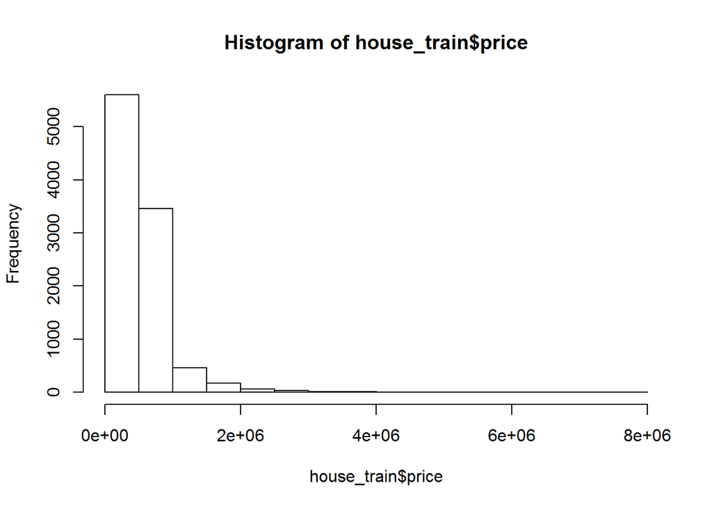

```r
hist(house_train$price)
```

La plotear la variable dependiente a estimar, junto con su relacion con la superficie, parece que si hay una relacion Lineal a pesar de haber outliers

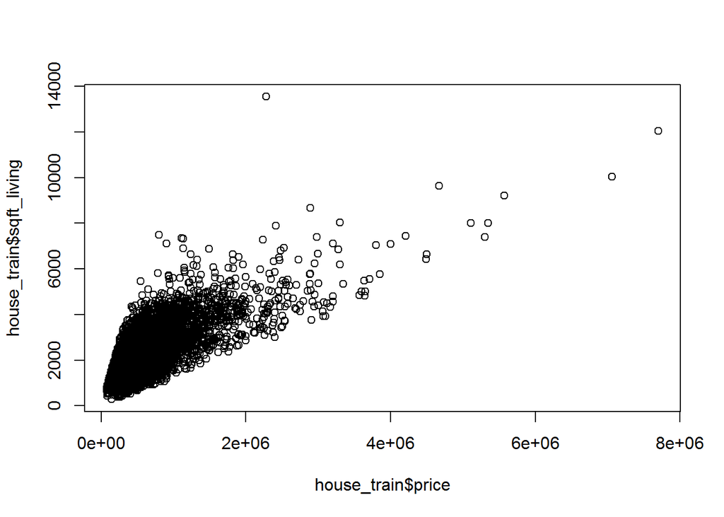

```r
plot(house_train$price,house_train$sqft_living)
```

No asi con la superficie de la parcela

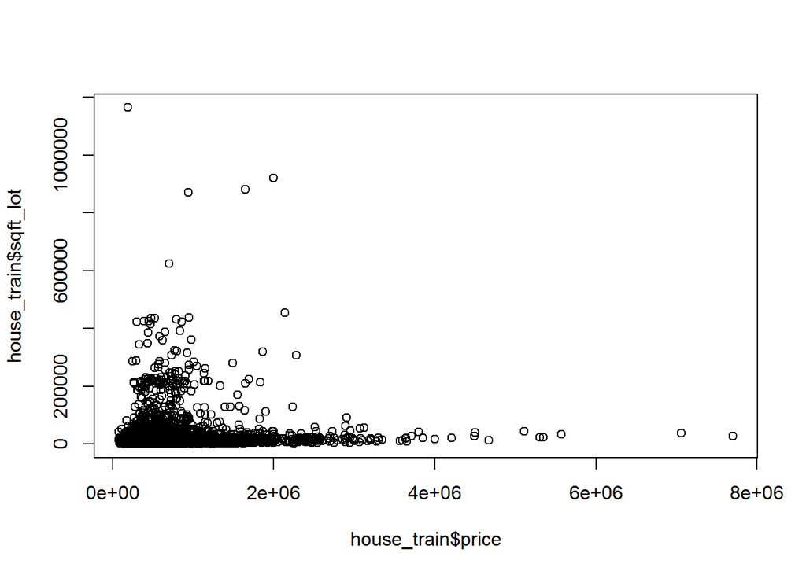

```r
plot(house_train$price,house_train$sqft_lot)
```

Aplicamos un modelo de regresion lineal para ver la relacion entre precio y metros cuadrados y estimar su comportamiento en base los parámetros del modelo y los residuos

Estimación de ventas en función al precio

```r
modelo1=lm(price~sqft_living,data=house_train)
summary(modelo1)
```

```
##
## Call:
## lm(formula = price ~ sqft_living, data = house_train)
##
## Residuals:
##      Min       1Q   Median       3Q      Max
## -1798927  -156415   -21360   113479  4080172
##
## Coefficients:
##               Estimate Std. Error t value Pr(>|t|)
## (Intercept) -93021.412   6881.515  -13.52   <2e-16 ***
## sqft_living    308.120      2.959  104.13   <2e-16 ***
## ---
## Signif. codes:  0 '***' 0.001 '**' 0.01 '*' 0.05 '.' 0.1 ' ' 1
##
## Residual standard error: 284000 on 9821 degrees of freedom
## Multiple R-squared:  0.5247, Adjusted R-squared:  0.5247
## F-statistic: 1.084e+04 on 1 and 9821 DF,  p-value: < 2.2e-16
```

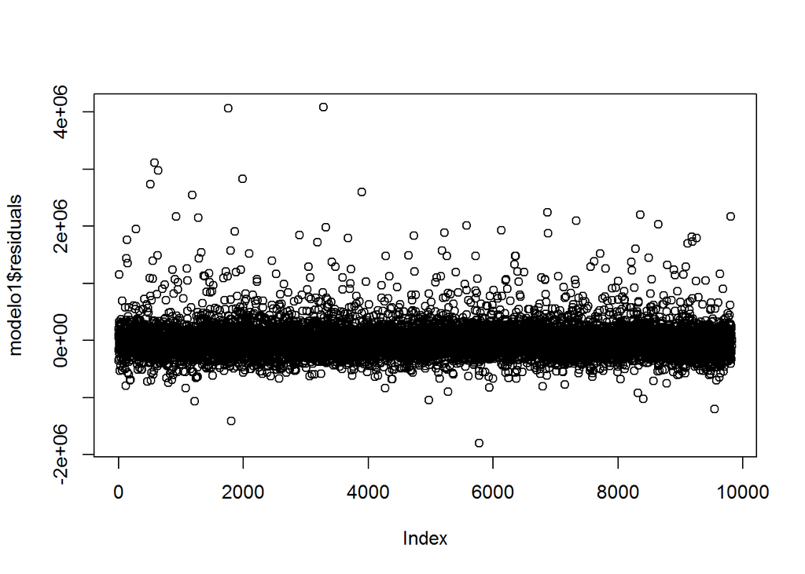

```r
plot(modelo1$residuals)
```

vemos que el comportamiento es bueno, aunque hay muchos valores dispersos por la parte alta

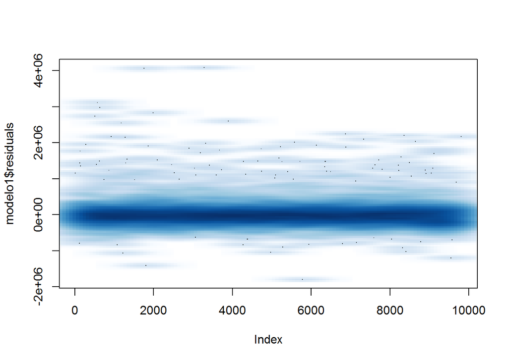

```r
smoothScatter(modelo1$residuals)
```

Se acercan a una normal muy picuda, es decir, que están muy concentrados.

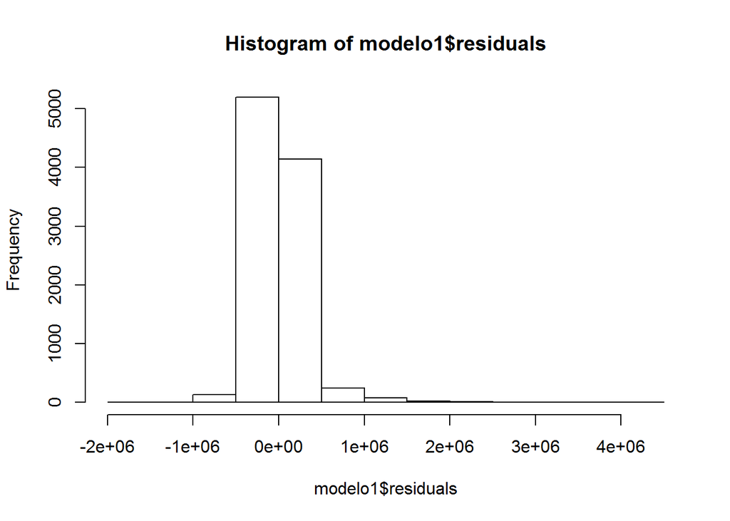

```r
hist(modelo1$residuals)
```

Vemos que por el qqnorm en los valores extremos, no podemos explicar el comportamiento.

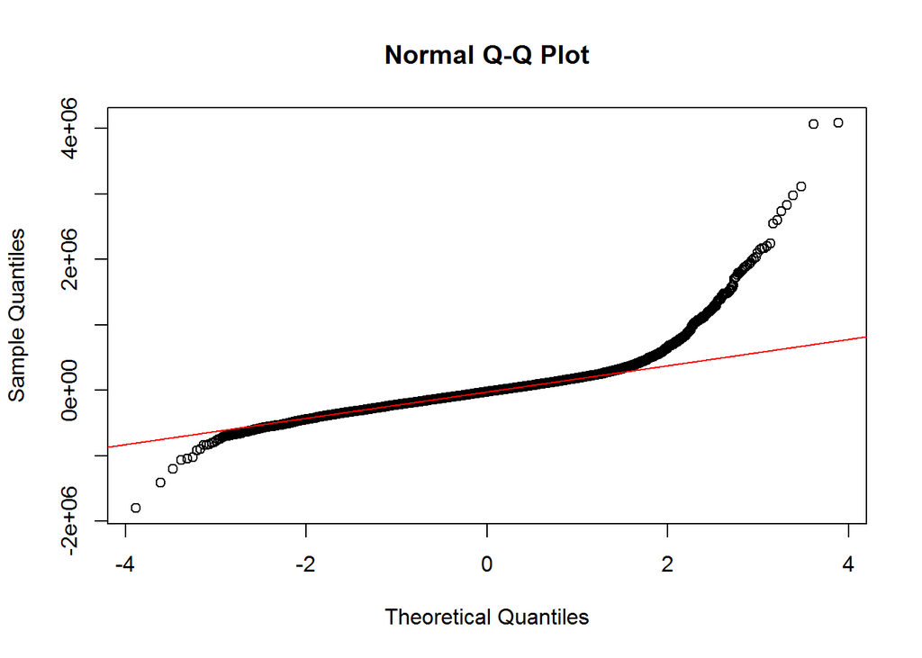

```r
qqnorm(modelo1$residuals); qqline(modelo1$residuals,col=2)
```

```r
confint(modelo1,level=0.95)
```

```
##                    2.5 %      97.5 %
## (Intercept) -106510.5954 -79532.2280
## sqft_living     302.3198    313.9207
```

Se me ocurre en este punto que: +debemos aplicar una transformacion al precio, ya que no cumple la hipotesis de normalidad +tendremos que aplicar una rlm asi como suavizar los bordes, ya que tenemos problemas con los valores extremos

No hemos detectado cambios estructurales extremos

Puesto que la variable del precio no sigue valores normales, sino aprarentemente mas una distrbucion de poisson, aplicamos una transformacion logaritmica y comprobamos los resultados.

Aplicamos la transformacion y comprobamos

```r
modelo2=lm(log(price)~sqft_living,data=house_train)
summary(modelo2)
```

```
##
## Call:
## lm(formula = log(price) ~ sqft_living, data = house_train)
##
## Residuals:
##      Min       1Q   Median       3Q      Max
## -3.07827 -0.29301  0.01847  0.26781  1.26645
##
## Coefficients:
##              Estimate Std. Error t value Pr(>|t|)
## (Intercept) 1.220e+01  9.375e-03    1302   <2e-16 ***
## sqft_living 4.073e-04  4.031e-06     101   <2e-16 ***
## ---
## Signif. codes:  0 '***' 0.001 '**' 0.01 '*' 0.05 '.' 0.1 ' ' 1
##
## Residual standard error: 0.3869 on 9821 degrees of freedom
## Multiple R-squared:  0.5097, Adjusted R-squared:  0.5097
## F-statistic: 1.021e+04 on 1 and 9821 DF,  p-value: < 2.2e-16
```

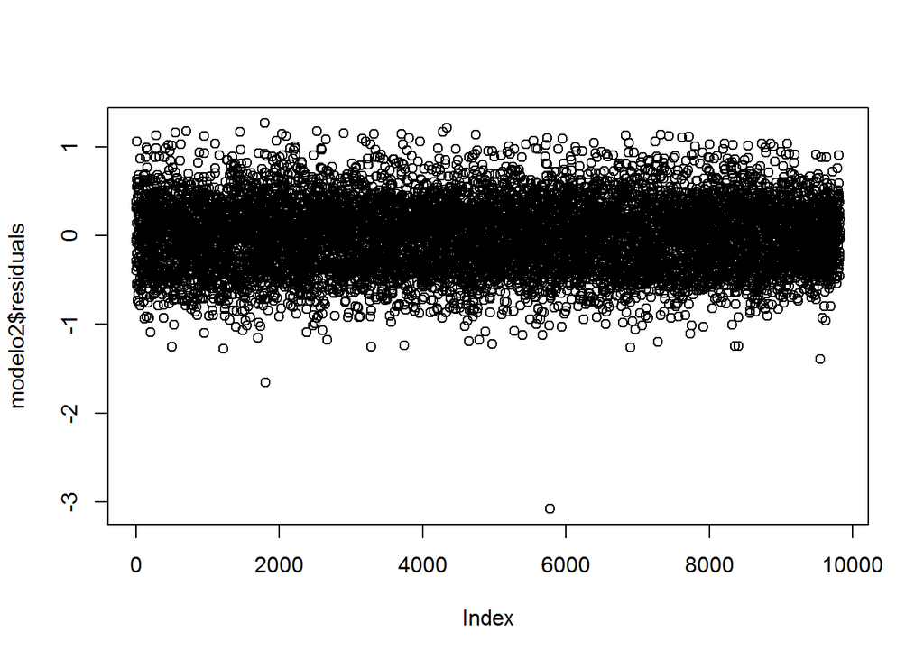

```r
plot(modelo2$residuals)
```

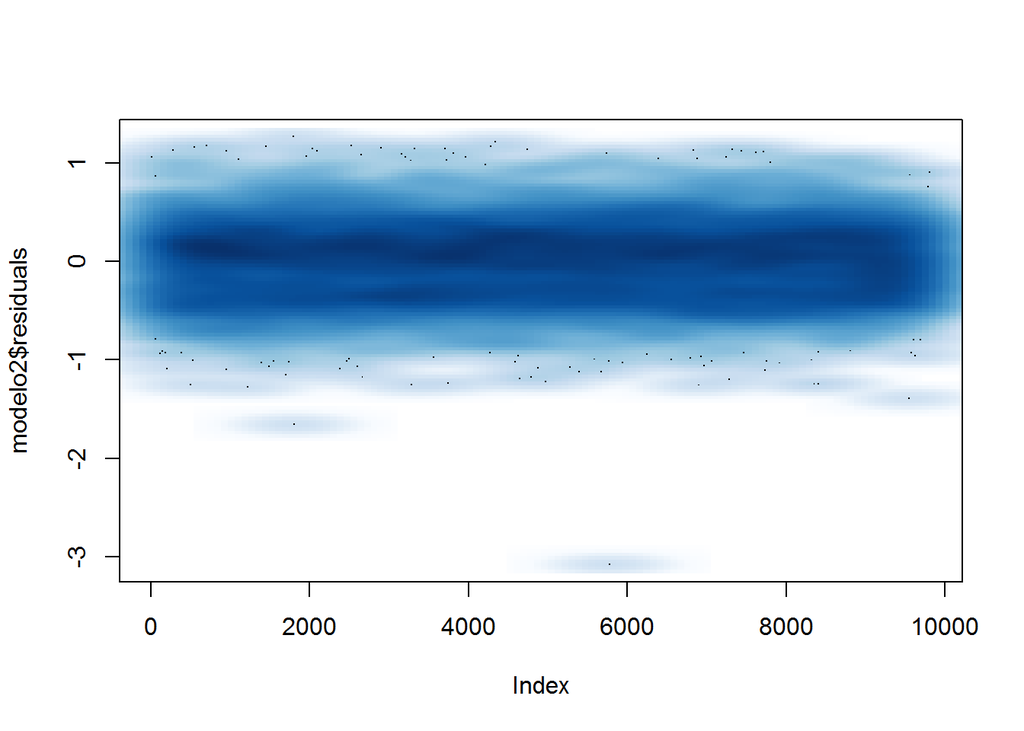

```r
smoothScatter(modelo2$residuals)
```

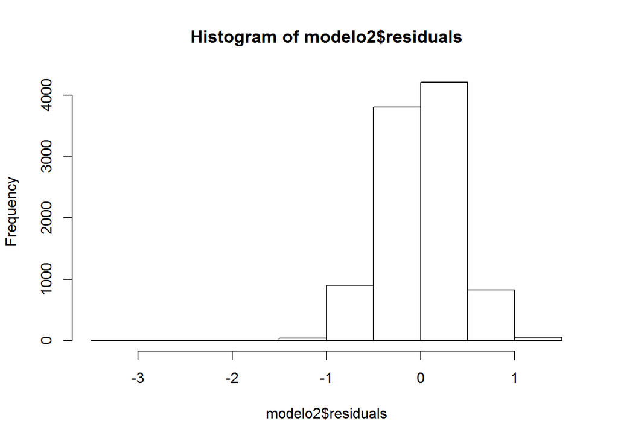

```r
hist(modelo2$residuals)
```

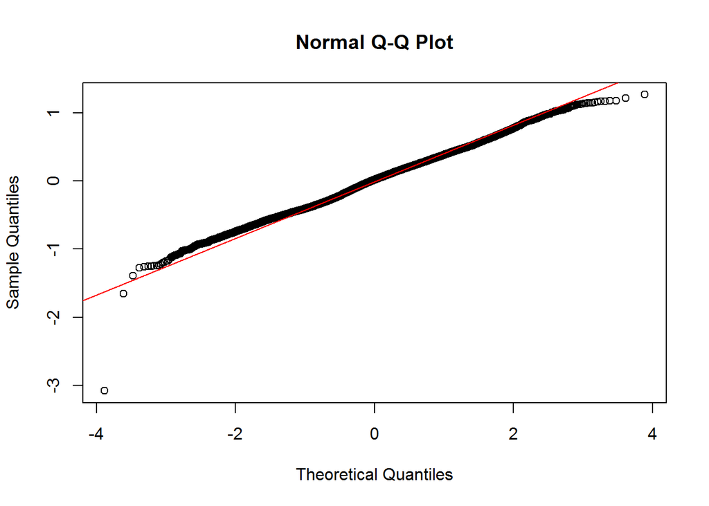

```r
qqnorm(modelo2$residuals); qqline(modelo2$residuals,col=2)
```

```r
confint(modelo2,level=0.95)
```

```
##                    2.5 %       97.5 %
## (Intercept) 1.218412e+01 1.222087e+01
## sqft_living 3.994434e-04 4.152479e-04
```

- la gráfica de disperion de los errores está muy centrada en torno al cero
- la visualizacion del qqplot se ajusta muy bien excepto en los extremos que hay un poco de variacion.

Como primera conclusión, un modelo transformado ajusta mejor. La variabilidad de los errores (R2 ajustado) es practicamente la misma en ambos casos.Aplicamos semielasticidad al modelo (transformacion en una de las variables)

El siguente paso sería calcular las correlaciones parciales, para ver aquellas que mas aportan al modelo lo ideal seria utilizar la correlacion parcial, que elimina los efectos de una variable sobre las demas evitando asi la multicolinealidad, pero las librerías que he usado no me funcionan, asi que utilizaré la correlacion normal, intentado detectar el overfitting con el comportamiento de los residuos.

```r
library(ggm)
```

```r
library(igraph)

houses_cor <- house_train
houses_cor$date = as.numeric(houses_cor$date)
houses_cor$bedrooms = as.numeric(houses_cor$bedrooms)
houses_cor$floors = as.numeric(houses_cor$floors)
houses_cor$waterfront = as.numeric(houses_cor$waterfront)
houses_cor$view = as.numeric(houses_cor$view)
houses_cor$condition = as.numeric(houses_cor$condition)
houses_cor$grade = as.numeric(houses_cor$grade)
houses_cor$yr_built = as.numeric(houses_cor$yr_built)
houses_cor$yr_renovated = as.numeric(houses_cor$yr_renovated)
houses_cor$zipcode = as.numeric(houses_cor$zipcode)
#library(parcor)
#parcor(houses_cor)


cor(houses_cor)
```

```
##                        date        price     bedrooms sqft_living
## date           1.0000000000  0.006917615 -0.006375131 -0.03410013
## price          0.0069176152  1.000000000  0.320117459  0.72436784
## bedrooms      -0.0063751313  0.320117459  1.000000000  0.59407680
## sqft_living   -0.0341001320  0.724367843  0.594076801  1.00000000
## sqft_lot       0.0006560856  0.104784049  0.033063979  0.19267642
## floors        -0.0224592016  0.254741170  0.198487882  0.36652597
## waterfront    -0.0174322749  0.293790651  0.003039034  0.12711161
## view           0.0062810344  0.408058017  0.093777825  0.30161151
## condition     -0.0400711377  0.027149181  0.019551890 -0.06502594
## grade         -0.0275074284  0.675840043  0.381066304  0.77446346
## sqft_above    -0.0297814634  0.628470012  0.502586404  0.88396880
## sqft_basement -0.0161503687  0.351000918  0.312347730  0.45337892
## yr_built      -0.0087747226  0.056650657  0.174990280  0.31406916
## yr_renovated  -0.0313415781  0.156493097  0.027917297  0.07994546
## zipcode       -0.0018282743 -0.073283827 -0.160766925 -0.19446490
## sqft_living15 -0.0212248020  0.589375399  0.417177572  0.76233137
## sqft_lot15    -0.0051288077  0.089580338  0.041870130  0.19302214
##                    sqft_lot       floors   waterfront         view
## date           0.0006560856 -0.022459202 -0.017432275  0.006281034
## price          0.1047840491  0.254741170  0.293790651  0.408058017
## bedrooms       0.0330639791  0.198487882  0.003039034  0.093777825
## sqft_living    0.1926764227  0.366525971  0.127111609  0.301611509
## sqft_lot       1.0000000000  0.013165823  0.014592462  0.090018640
## floors         0.0131658231  1.000000000  0.024727195  0.026235827
## waterfront     0.0145924620  0.024727195  1.000000000  0.405992096
## view           0.0900186403  0.026235827  0.405992096  1.000000000
## condition     -0.0210847009 -0.265576885  0.008876546  0.040804196
## grade          0.1430635281  0.462869382  0.093127101  0.260982403
## sqft_above     0.1971878914  0.530295962  0.096257919  0.182669716
## sqft_basement  0.0361350452 -0.227107076  0.088331474  0.296775822
## yr_built       0.0671448855  0.497088292 -0.023525885 -0.048808690
## yr_renovated   0.0071197806  0.007289596  0.073370919  0.095219407
## zipcode       -0.1248279088 -0.042372353  0.022458923  0.053340084
## sqft_living15  0.1636001153  0.294165479  0.078594493  0.287675108
## sqft_lot15     0.7487538181  0.003851959  0.018576744  0.082395563
##                  condition       grade  sqft_above sqft_basement
## date          -0.040071138 -0.02750743 -0.02978146   -0.01615037
## price          0.027149181  0.67584004  0.62847001    0.35100092
## bedrooms       0.019551890  0.38106630  0.50258640    0.31234773
```

[output cut: 35 more lines]

```
## bedrooms       0.041870130
## sqft_living    0.193022142
## sqft_lot       0.748753818
## floors         0.003851959
## waterfront     0.018576744
## view           0.082395563
## condition     -0.008535028
## grade          0.138421223
## sqft_above     0.195275076
## sqft_basement  0.040520929
## yr_built       0.081208265
## yr_renovated   0.009322497
## zipcode       -0.136377661
## sqft_living15  0.185296674
## sqft_lot15     1.000000000
```

vamos a analizar la aportacion de las distintas variables al modelo, con varias simulaciones.

De esta manera, nos permitirá ir reduciendo aquellas que no aporten.

```r
modelo3=lm(log(price)~.,data=house_train)
summary(modelo3)
```

```
##
## Call:
## lm(formula = log(price) ~ ., data = house_train)
##
## Residuals:
##      Min       1Q   Median       3Q      Max
## -1.28538 -0.09354  0.00462  0.10022  0.95035
##
## Coefficients: (1 not defined because of singularities)
##                    Estimate Std. Error t value Pr(>|t|)
## (Intercept)       1.129e+01  1.867e-01  60.476  < 2e-16 ***
## date2015          5.515e-02  3.974e-03  13.877  < 2e-16 ***
## bedrooms1         7.741e-02  7.916e-02   0.978 0.328148
## bedrooms2         9.486e-02  7.738e-02   1.226 0.220271
## bedrooms3         1.398e-01  7.727e-02   1.809 0.070460 .
## bedrooms4         1.497e-01  7.739e-02   1.934 0.053145 .
## bedrooms5         1.189e-01  7.772e-02   1.530 0.125975
## bedrooms6         1.361e-01  7.929e-02   1.717 0.086058 .
## bedrooms7        -5.674e-02  8.956e-02  -0.633 0.526439
## bedrooms8         3.685e-02  1.128e-01   0.327 0.743820
## bedrooms9         1.006e-01  1.516e-01   0.664 0.506923
## bedrooms10       -3.100e-01  1.978e-01  -1.568 0.117023
## sqft_living       1.439e-04  5.510e-06  26.120  < 2e-16 ***
## sqft_lot          7.722e-07  7.576e-08  10.192  < 2e-16 ***
## floors1.5        -7.013e-03  8.154e-03  -0.860 0.389737
## floors2          -4.173e-02  6.915e-03  -6.035 1.65e-09 ***
## floors2.5        -5.435e-02  2.199e-02  -2.471 0.013472 *
## floors3          -1.565e-01  1.430e-02 -10.946  < 2e-16 ***
## floors3.5        -2.410e-01  1.289e-01  -1.870 0.061481 .
## waterfront1       5.090e-01  2.733e-02  18.622  < 2e-16 ***
## view1             1.186e-01  1.526e-02   7.774 8.37e-15 ***
## view2             1.142e-01  9.154e-03  12.473  < 2e-16 ***
## view3             1.763e-01  1.283e-02  13.740  < 2e-16 ***
## view4             2.500e-01  1.980e-02  12.627  < 2e-16 ***
## condition2        1.903e-02  5.733e-02   0.332 0.739963
## condition3        1.578e-01  5.384e-02   2.932 0.003377 **
## condition4        2.132e-01  5.391e-02   3.956 7.68e-05 ***
## condition5        2.815e-01  5.419e-02   5.195 2.09e-07 ***
## grade3           -1.842e-02  2.443e-01  -0.075 0.939897
## grade4            1.041e-01  2.088e-01   0.499 0.618051
```

[output cut: 251 more lines]

```
## zipcode98166      3.062e-01  2.215e-02  13.824  < 2e-16 ***
## zipcode98168      7.101e-02  2.281e-02   3.112 0.001861 **
## zipcode98177      6.056e-01  2.306e-02  26.259  < 2e-16 ***
## zipcode98178      1.533e-01  2.131e-02   7.193 6.81e-13 ***
## zipcode98188      9.063e-02  2.641e-02   3.431 0.000603 ***
## zipcode98198      4.480e-02  2.193e-02   2.042 0.041140 *
## zipcode98199      8.246e-01  2.156e-02  38.240  < 2e-16 ***
## sqft_living15     8.142e-05  4.887e-06  16.659  < 2e-16 ***
## sqft_lot15        7.619e-11  1.053e-07   0.001 0.999423
## ---
## Signif. codes:  0 '***' 0.001 '**' 0.01 '*' 0.05 '.' 0.1 ' ' 1
##
## Residual standard error: 0.1803 on 9534 degrees of freedom
## Multiple R-squared:  0.8967, Adjusted R-squared:  0.8935
## F-statistic: 287.3 on 288 and 9534 DF,  p-value: < 2.2e-16
```

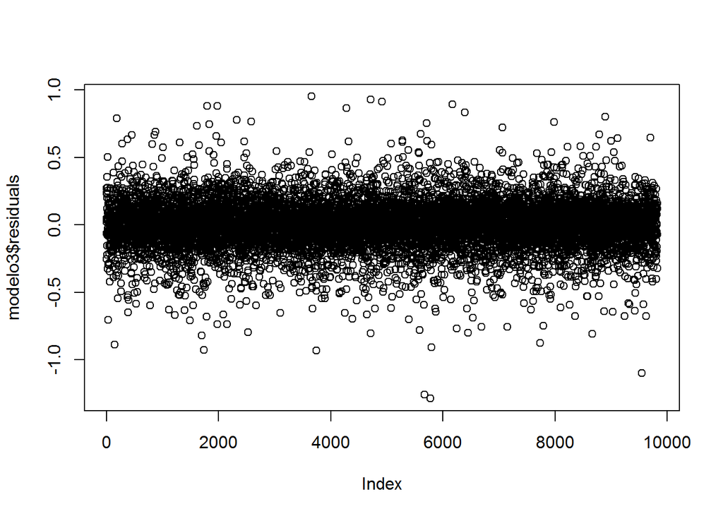

```r
plot(modelo3$residuals)
```

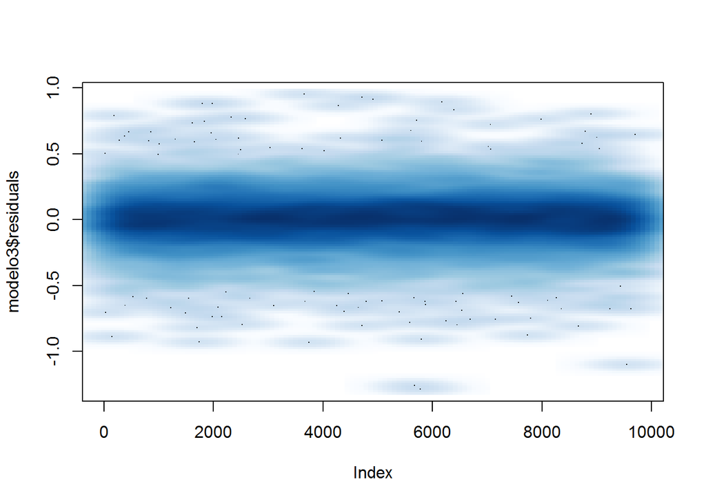

```r
smoothScatter(modelo3$residuals)
```

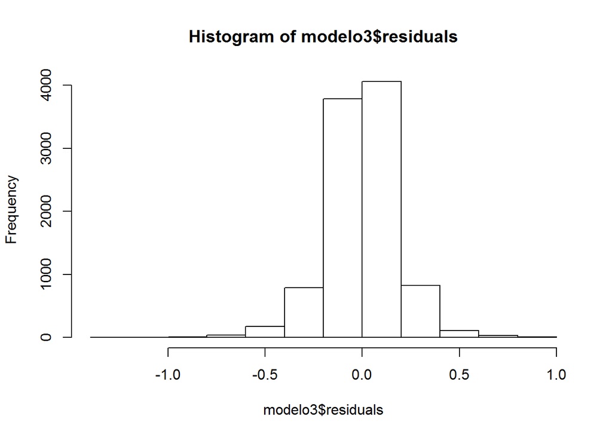

```r
hist(modelo3$residuals)
```

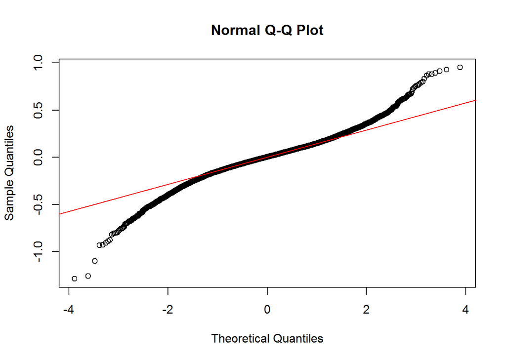

```r
qqnorm(modelo3$residuals); qqline(modelo3$residuals,col=2)
```

```r
confint(modelo3,level=0.95)
```

```
##                          2.5 %        97.5 %
## (Intercept)       1.092210e+01  1.165386e+01
## date2015          4.735611e-02  6.293532e-02
## bedrooms1        -7.776321e-02  2.325912e-01
## bedrooms2        -5.682071e-02  2.465351e-01
## bedrooms3        -1.167268e-02  2.912439e-01
## bedrooms4        -2.030287e-03  3.013836e-01
## bedrooms5        -3.341239e-02  2.712798e-01
## bedrooms6        -1.930487e-02  2.915514e-01
## bedrooms7        -2.323024e-01  1.188287e-01
## bedrooms8        -1.841727e-01  2.578704e-01
## bedrooms9        -1.965494e-01  3.977637e-01
## bedrooms10       -6.977502e-01  7.766716e-02
## sqft_living       1.331287e-04  1.547317e-04
## sqft_lot          6.236975e-07  9.207253e-07
## floors1.5        -2.299677e-02  8.969909e-03
## floors2          -5.528736e-02 -2.817765e-02
## floors2.5        -9.746384e-02 -1.124422e-02
## floors3          -1.845778e-01 -1.285112e-01
## floors3.5        -4.936097e-01  1.159437e-02
## waterfront1       4.554129e-01  5.625668e-01
## view1             8.872368e-02  1.485493e-01
## view2             9.623957e-02  1.321287e-01
## view3             1.511820e-01  2.014970e-01
## view4             2.112073e-01  2.888350e-01
## condition2       -9.335533e-02  1.314143e-01
## condition3        5.231385e-02  2.633857e-01
## condition4        1.075728e-01  3.189056e-01
## condition5        1.752664e-01  3.877040e-01
## grade3           -4.973830e-01  4.605357e-01
## grade4           -3.051639e-01  5.133826e-01
## grade5           -3.347486e-01  4.747896e-01
## grade6           -2.099831e-01  5.996278e-01
## grade7           -6.793993e-02  7.415018e-01
## grade8            3.943210e-02  8.494409e-01
## grade9            1.344961e-01  9.451922e-01
## grade10           1.975235e-01  1.009205e+00
## grade11           2.224421e-01  1.036121e+00
## grade12           2.499961e-01  1.068970e+00
## grade13           2.308950e-01  1.076058e+00
```

[output cut: 236 more lines]

```
## zipcode98133      4.281992e-01  5.029646e-01
## zipcode98136      6.303644e-01  7.191170e-01
## zipcode98144      6.192540e-01  7.015871e-01
## zipcode98146      2.083830e-01  2.938168e-01
## zipcode98148      9.927967e-02  2.570300e-01
## zipcode98155      4.015572e-01  4.789491e-01
## zipcode98166      2.627626e-01  3.495938e-01
## zipcode98168      2.628927e-02  1.157333e-01
## zipcode98177      5.603561e-01  6.507671e-01
## zipcode98178      1.114964e-01  1.950276e-01
## zipcode98188      3.885764e-02  1.424006e-01
## zipcode98198      1.802466e-03  8.778991e-02
## zipcode98199      7.823247e-01  8.668642e-01
## sqft_living15     7.183590e-05  9.099554e-05
## sqft_lot15       -2.063922e-07  2.065445e-07
```

El modelo 3 nos indica cuales de las variables no son significativas para le modelo. Entre ellas: + aquellas que no tienen *: bedrooms, sqft_basement,yr_built, yr_renovated.

- Evidentemente, algunas de las variables anteriores, al ser factores, aportan cuando hay datos, pero no aportan cuando no los hay, con lo cual pueden deshecharse las variables

+En este caso el R2 es elevado R-squared: 0.8866, eso indica que puede explicarse el 88% de la variabilidad de los datos.

Eliminamos del modelo las variables que hemos visto que no aportan.

```r
modelo4=lm(log(price)~sqft_living+grade+sqft_above+sqft_living15+view+waterfront+zipcode,data=house_train)
summary(modelo4)
```

```
##
## Call:
## lm(formula = log(price) ~ sqft_living + grade + sqft_above +
##     sqft_living15 + view + waterfront + zipcode, data = house_train)
##
## Residuals:
##      Min       1Q   Median       3Q      Max
## -1.55104 -0.10296  0.00616  0.10777  1.05667
##
## Coefficients:
##                 Estimate Std. Error t value Pr(>|t|)
## (Intercept)    1.112e+01  1.966e-01  56.572  < 2e-16 ***
## sqft_living    1.739e-04  5.043e-06  34.478  < 2e-16 ***
## grade3         3.885e-01  2.397e-01   1.620 0.105174
## grade4         4.944e-01  2.041e-01   2.423 0.015432 *
## grade5         5.165e-01  1.968e-01   2.625 0.008687 **
## grade6         6.373e-01  1.960e-01   3.251 0.001153 **
## grade7         7.569e-01  1.960e-01   3.862 0.000113 ***
## grade8         8.418e-01  1.961e-01   4.293 1.78e-05 ***
## grade9         9.341e-01  1.962e-01   4.760 1.96e-06 ***
## grade10        9.944e-01  1.965e-01   5.061 4.25e-07 ***
## grade11        9.990e-01  1.970e-01   5.071 4.03e-07 ***
## grade12        1.017e+00  1.984e-01   5.124 3.05e-07 ***
## grade13        1.004e+00  2.062e-01   4.869 1.14e-06 ***
## sqft_above     4.539e-05  5.681e-06   7.991 1.49e-15 ***
## sqft_living15  9.000e-05  5.070e-06  17.752  < 2e-16 ***
## view1          1.176e-01  1.604e-02   7.331 2.46e-13 ***
## view2          1.225e-01  9.637e-03  12.708  < 2e-16 ***
## view3          1.879e-01  1.354e-02  13.879  < 2e-16 ***
## view4          2.616e-01  2.082e-02  12.563  < 2e-16 ***
## waterfront1    4.994e-01  2.853e-02  17.505  < 2e-16 ***
## zipcode98002   9.842e-03  2.573e-02   0.382 0.702151
## zipcode98003   1.881e-02  2.225e-02   0.845 0.397973
## zipcode98004   1.130e+00  2.174e-02  51.994  < 2e-16 ***
## zipcode98005   7.730e-01  2.696e-02  28.675  < 2e-16 ***
## zipcode98006   6.592e-01  1.961e-02  33.611  < 2e-16 ***
## zipcode98007   6.648e-01  3.037e-02  21.889  < 2e-16 ***
## zipcode98008   6.819e-01  2.280e-02  29.908  < 2e-16 ***
## zipcode98010   3.106e-01  3.413e-02   9.101  < 2e-16 ***
## zipcode98011   4.487e-01  2.684e-02  16.718  < 2e-16 ***
```

[output cut: 51 more lines]

```
## zipcode98148   1.345e-01  4.225e-02   3.183 0.001462 **
## zipcode98155   4.443e-01  2.065e-02  21.514  < 2e-16 ***
## zipcode98166   3.140e-01  2.314e-02  13.566  < 2e-16 ***
## zipcode98168   4.157e-02  2.387e-02   1.742 0.081543 .
## zipcode98177   6.091e-01  2.402e-02  25.358  < 2e-16 ***
## zipcode98178   1.339e-01  2.227e-02   6.011 1.90e-09 ***
## zipcode98188   7.409e-02  2.786e-02   2.659 0.007842 **
## zipcode98198   3.541e-02  2.323e-02   1.524 0.127451
## zipcode98199   8.471e-01  2.228e-02  38.024  < 2e-16 ***
## ---
## Signif. codes:  0 '***' 0.001 '**' 0.01 '*' 0.05 '.' 0.1 ' ' 1
##
## Residual standard error: 0.1935 on 9734 degrees of freedom
## Multiple R-squared:  0.8785, Adjusted R-squared:  0.8774
## F-statistic: 799.8 on 88 and 9734 DF,  p-value: < 2.2e-16
```

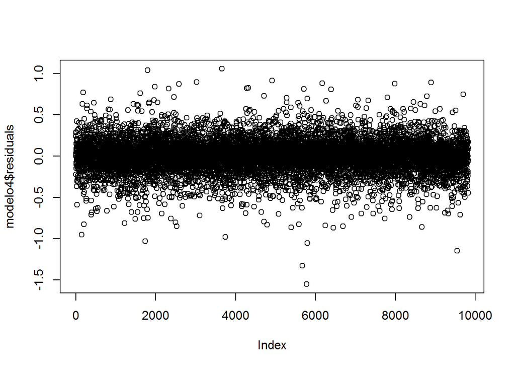

```r
plot(modelo4$residuals)
```

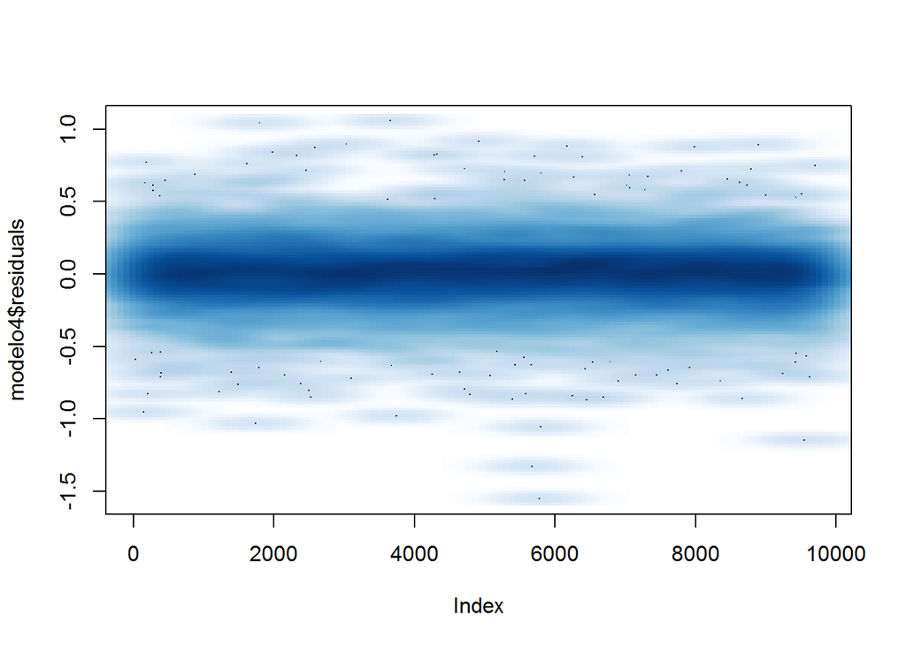

```r
smoothScatter(modelo4$residuals)
```

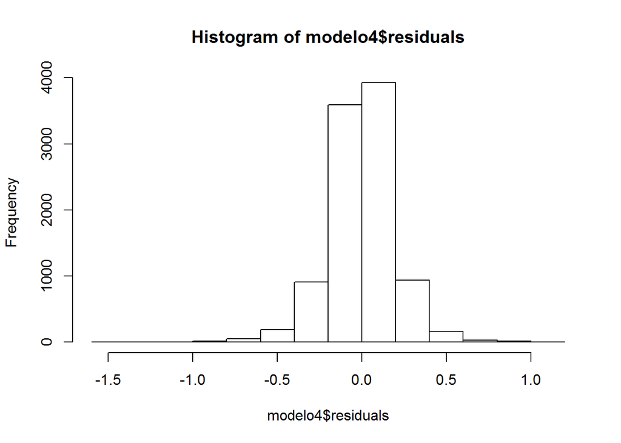

```r
hist(modelo4$residuals)
```

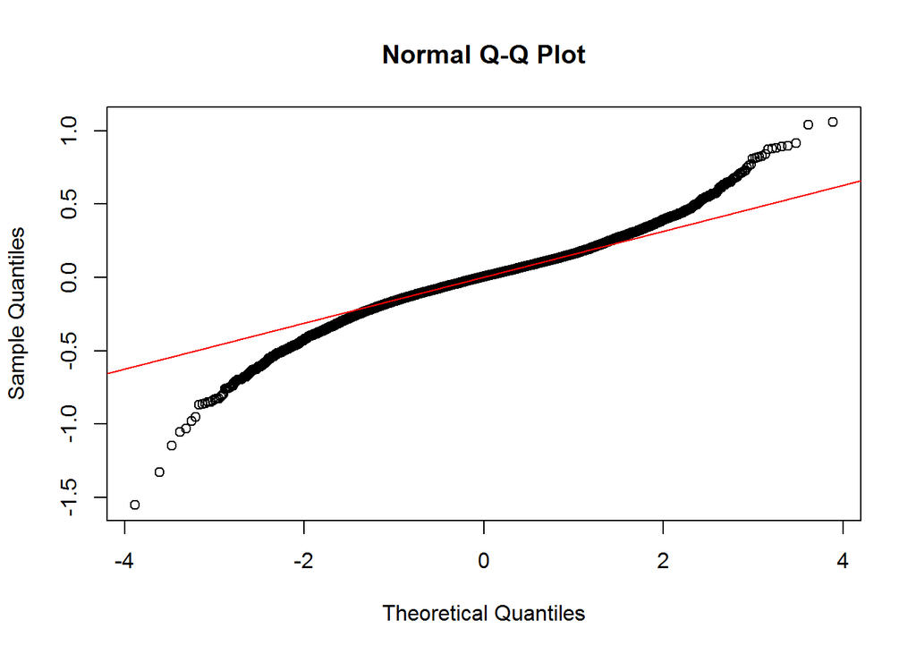

```r
qqnorm(modelo4$residuals); qqline(modelo4$residuals,col=2)
```

```r
confint(modelo4,level=0.95)
```

```
##                       2.5 %       97.5 %
## (Intercept)    1.073629e+01 1.150701e+01
## sqft_living    1.639786e-04 1.837485e-04
## grade3        -8.146349e-02 8.584506e-01
## grade4         9.434236e-02 8.943984e-01
## grade5         1.307466e-01 9.021794e-01
## grade6         2.530710e-01 1.021586e+00
## grade7         3.727155e-01 1.141108e+00
## grade8         4.574370e-01 1.226140e+00
## grade9         5.493964e-01 1.318712e+00
## grade10        6.092690e-01 1.379568e+00
## grade11        6.128223e-01 1.385141e+00
## grade12        6.276507e-01 1.405421e+00
## grade13        5.999247e-01 1.408428e+00
## sqft_above     3.425592e-05 5.652593e-05
## sqft_living15  8.006114e-05 9.993717e-05
## view1          8.615634e-02 1.490437e-01
## view2          1.035823e-01 1.413645e-01
## view3          1.613456e-01 2.144176e-01
## view4          2.207911e-01 3.024257e-01
## waterfront1    4.434741e-01 5.553216e-01
## zipcode98002  -4.060351e-02 6.028688e-02
## zipcode98003  -2.480373e-02 6.241378e-02
## zipcode98004   1.087555e+00 1.172770e+00
## zipcode98005   7.201295e-01 8.258103e-01
## zipcode98006   6.207843e-01 6.976776e-01
## zipcode98007   6.053003e-01 7.243764e-01
## zipcode98008   6.371633e-01 7.265418e-01
## zipcode98010   2.436996e-01 3.775013e-01
## zipcode98011   3.960850e-01 5.013027e-01
## zipcode98014   2.300133e-01 3.613046e-01
## zipcode98019   2.805909e-01 3.857136e-01
## zipcode98022   4.883863e-02 1.463060e-01
## zipcode98023  -7.609275e-02 1.835958e-03
## zipcode98024   4.656153e-01 5.994838e-01
## zipcode98027   4.686247e-01 5.502184e-01
## zipcode98028   3.574124e-01 4.480877e-01
## zipcode98029   5.304303e-01 6.174454e-01
## zipcode98030   1.882369e-02 1.100787e-01
## zipcode98031   5.519967e-02 1.441838e-01
```

[output cut: 35 more lines]

```
## zipcode98125   5.473198e-01 6.299139e-01
## zipcode98126   5.379971e-01 6.274471e-01
## zipcode98133   4.214636e-01 4.994778e-01
## zipcode98136   6.342287e-01 7.261905e-01
## zipcode98144   6.439348e-01 7.285770e-01
## zipcode98146   1.988157e-01 2.876438e-01
## zipcode98148   5.166414e-02 2.172982e-01
## zipcode98155   4.038038e-01 4.847625e-01
## zipcode98166   2.686055e-01 3.593413e-01
## zipcode98168  -5.208097e-03 8.835589e-02
## zipcode98177   5.620278e-01 6.561963e-01
## zipcode98178   9.022246e-02 1.775318e-01
## zipcode98188   1.947729e-02 1.286936e-01
## zipcode98198  -1.012500e-02 8.094915e-02
## zipcode98199   8.034611e-01 8.908035e-01
```

Vemos en este caso, que con muchas menos variables, somos capaces de explicar practicamente la misma variabilidad del modelo, sin embargo, el análisis de los residuos, vemos en el qqplot que se nos alejan de los extremos, con lo que el grado de predictividad del modelo no es del todo bueno

Eliminamos la variable del zipcode, el cual como podemos ver en los resultados, explicaba muy bien la variabilidad de los resultados, pero hacia que el modelo entrase en overfitting, de manera que ahoralos residuos se ajustan mucho mejor a la linea dentro del qqplot. Los residuos también están perfectamente ajustados a una normal con media 0.

```r
modelo5=lm(log(price)~sqft_living+grade+sqft_above+sqft_living15+view+waterfront,data=house_train)
summary(modelo5)
```

```
##
## Call:
## lm(formula = log(price) ~ sqft_living + grade + sqft_above +
##     sqft_living15 + view + waterfront, data = house_train)
##
## Residuals:
##      Min       1Q   Median       3Q      Max
## -1.57586 -0.24200  0.00576  0.23183  1.24370
##
## Coefficients:
##                 Estimate Std. Error t value Pr(>|t|)
## (Intercept)    1.171e+01  3.445e-01  33.996  < 2e-16 ***
## sqft_living    2.513e-04  8.697e-06  28.896  < 2e-16 ***
## grade3        -3.078e-02  4.216e-01  -0.073 0.941797
## grade4         3.971e-01  3.596e-01   1.104 0.269504
## grade5         3.383e-01  3.458e-01   0.978 0.327965
## grade6         5.170e-01  3.445e-01   1.501 0.133498
## grade7         7.275e-01  3.444e-01   2.112 0.034680 *
## grade8         9.121e-01  3.445e-01   2.647 0.008123 **
## grade9         1.136e+00  3.448e-01   3.295 0.000989 ***
## grade10        1.306e+00  3.452e-01   3.784 0.000155 ***
## grade11        1.408e+00  3.461e-01   4.069 4.76e-05 ***
## grade12        1.517e+00  3.485e-01   4.353 1.35e-05 ***
## grade13        1.637e+00  3.622e-01   4.521 6.23e-06 ***
## sqft_above    -1.089e-04  9.480e-06 -11.484  < 2e-16 ***
## sqft_living15  6.911e-05  8.311e-06   8.315  < 2e-16 ***
## view1          2.428e-01  2.811e-02   8.639  < 2e-16 ***
## view2          1.556e-01  1.670e-02   9.317  < 2e-16 ***
## view3          1.776e-01  2.357e-02   7.533 5.39e-14 ***
## view4          2.745e-01  3.646e-02   7.528 5.62e-14 ***
## waterfront1    4.187e-01  4.964e-02   8.435  < 2e-16 ***
## ---
## Signif. codes:  0 '***' 0.001 '**' 0.01 '*' 0.05 '.' 0.1 ' ' 1
##
## Residual standard error: 0.3442 on 9803 degrees of freedom
## Multiple R-squared:  0.6126, Adjusted R-squared:  0.6118
## F-statistic: 815.8 on 19 and 9803 DF,  p-value: < 2.2e-16
```

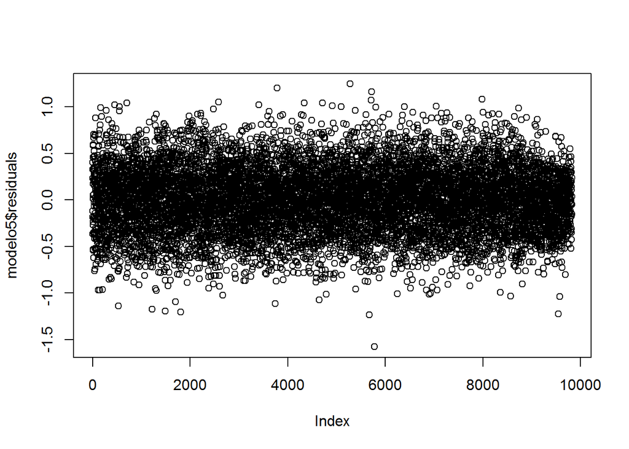

```r
plot(modelo5$residuals)
```

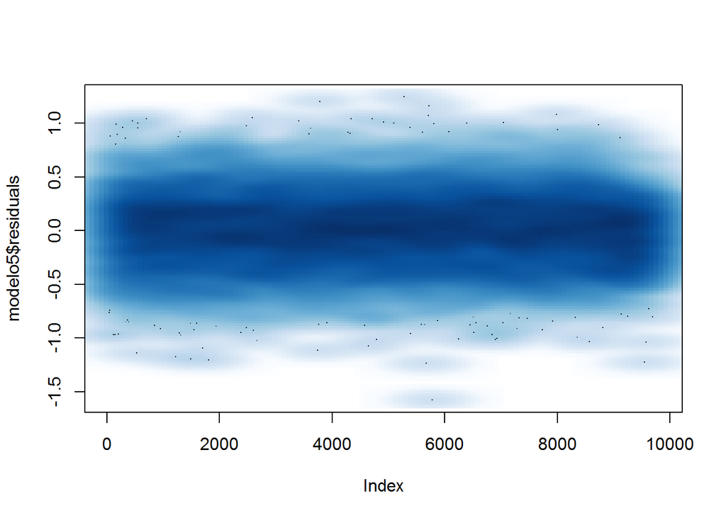

```r
smoothScatter(modelo5$residuals)
```

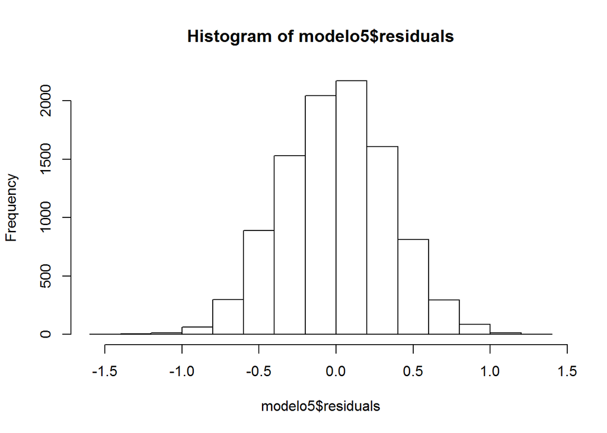

```r
hist(modelo5$residuals)
```

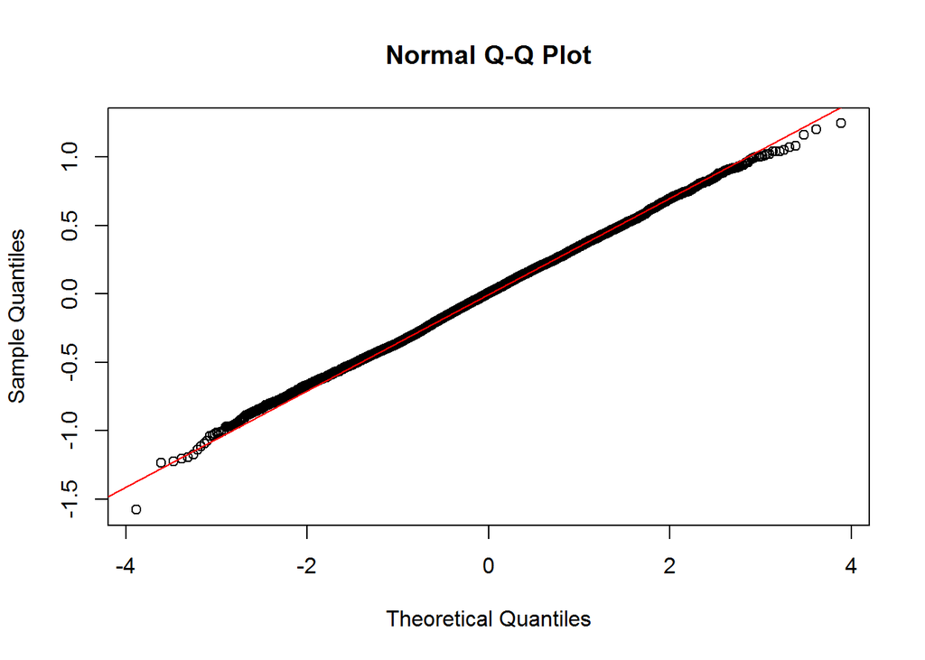

```r
qqnorm(modelo5$residuals); qqline(modelo5$residuals,col=2)
```

```r
confint(modelo5,level=0.95)
```

```
##                       2.5 %        97.5 %
## (Intercept)    1.103509e+01  1.238554e+01
## sqft_living    2.342597e-04  2.683557e-04
## grade3        -8.572567e-01  7.956884e-01
## grade4        -3.077628e-01  1.101870e+00
## grade5        -3.396019e-01  1.016269e+00
## grade6        -1.583473e-01  1.192268e+00
## grade7         5.240594e-02  1.402615e+00
## grade8         2.367639e-01  1.587359e+00
## grade9         4.600242e-01  1.811660e+00
## grade10        6.295135e-01  1.982669e+00
## grade11        7.298003e-01  2.086521e+00
## grade12        8.341268e-01  2.200499e+00
## grade13        9.273938e-01  2.347179e+00
## sqft_above    -1.274517e-04 -9.028566e-05
## sqft_living15  5.281818e-05  8.540098e-05
## view1          1.877116e-01  2.979038e-01
## view2          1.229000e-01  1.883897e-01
## view3          1.313731e-01  2.237895e-01
## view4          2.030097e-01  3.459628e-01
## waterfront1    3.214355e-01  5.160595e-01
```

Vamos a intentar ver el comportamiento del modelo que mejor predicie los resultados (modelo 5) frente a un modelo robusto y comprarlos, para ver que efectivamente el comportamiento es similar, indicativo de que vamos por buen camino.

```r
MediaWinsor<-function(x,probs=c(0.05,0.95)) {
  xq<-quantile(x,probs=probs)
  x[x < xq[1]]<-xq[1]
  x[x > xq[2]]<-xq[2]
  return(mean(x))
}

alphas=seq(from=0,to=0.5,by=0.01)
medias_recortadas=c()
medias_winsorizadas=c()
for (alpha in alphas){
  medias_recortadas=c(medias_recortadas,mean(house_train$price, trim=alpha))
  medias_winsorizadas=c(medias_winsorizadas,MediaWinsor(house_train$price,probs=c(alpha,1-alpha)))
}

Estimadores=data.frame(alphas)
Estimadores$media=mean(house_train$price)
Estimadores$mediana=median(house_train$price)
Estimadores$recortada=medias_recortadas
Estimadores$winsorizada=medias_winsorizadas

Estimadores
```

```
##    alphas    media mediana recortada winsorizada
## 1    0.00 558446.4  455000  558446.4    558446.4
## 2    0.01 558446.4  455000  537478.5    551154.6
## 3    0.02 558446.4  455000  526418.1    543780.8
## 4    0.03 558446.4  455000  518278.3    538635.7
## 5    0.04 558446.4  455000  511824.7    532809.0
## 6    0.05 558446.4  455000  506511.5    528353.4
## 7    0.06 558446.4  455000  502062.9    523682.2
## 8    0.07 558446.4  455000  498402.5    518480.7
## 9    0.08 558446.4  455000  495336.7    514302.5
## 10   0.09 558446.4  455000  492611.1    511840.7
## 11   0.10 558446.4  455000  490147.0    509111.8
## 12   0.11 558446.4  455000  487868.7    506808.3
## 13   0.12 558446.4  455000  485784.7    504013.3
## 14   0.13 558446.4  455000  483861.1    502185.0
```

[output cut: 37 more lines]

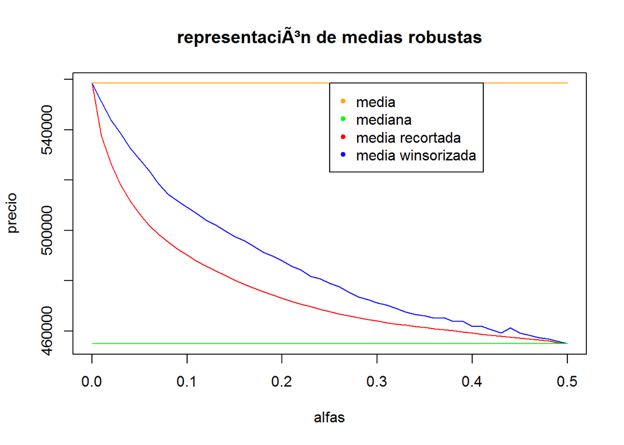

```r
plot(Estimadores$recortada~Estimadores$alphas,ylim=c(min(Estimadores[,2:5]),max(Estimadores[,2:5])),col="red",type="l", main="representaciÃ³n de medias robustas", xlab="alfas",ylab="precio")
lines(alphas,Estimadores$winsorizada,col="blue")
lines(alphas,Estimadores$media,col="orange")
lines(alphas,Estimadores$mediana,col="green")
legend(x=mean(alphas),y=max(Estimadores[,2:5]),legend=c("media","mediana","media recortada","media winsorizada"),col=c("orange","green","red","blue"),pch=20)
```

Generamos el modelo robusto para comprar

```r
library(MASS)
modelo6=rlm(log(price)~sqft_living+grade+sqft_above+sqft_living15+view+waterfront,data=house_train)
summary(modelo6)
```

```
##
## Call: rlm(formula = log(price) ~ sqft_living + grade + sqft_above +
##     sqft_living15 + view + waterfront, data = house_train)
## Residuals:
##       Min        1Q    Median        3Q       Max
## -1.645645 -0.241040  0.006605  0.232561  1.246844
##
## Coefficients:
##               Value    Std. Error t value
## (Intercept)    11.7330   0.3549    33.0558
## sqft_living     0.0003   0.0000    29.5753
## grade3         -0.0346   0.4345    -0.0795
## grade4          0.4494   0.3705     1.2129
## grade5          0.3399   0.3564     0.9539
## grade6          0.5195   0.3550     1.4634
## grade7          0.7273   0.3549     2.0495
## grade8          0.9201   0.3550     2.5920
## grade9          1.1490   0.3553     3.2343
## grade10         1.3254   0.3557     3.7265
## grade11         1.4393   0.3566     4.0362
## grade12         1.5758   0.3591     4.3879
## grade13         1.6770   0.3732     4.4940
## sqft_above     -0.0001   0.0000   -12.9395
## sqft_living15   0.0001   0.0000     6.5136
## view1           0.2407   0.0290     8.3114
## view2           0.1578   0.0172     9.1667
## view3           0.1798   0.0243     7.4031
## view4           0.3067   0.0376     8.1626
## waterfront1     0.3906   0.0512     7.6359
##
## Residual standard error: 0.3486 on 9803 degrees of freedom
```

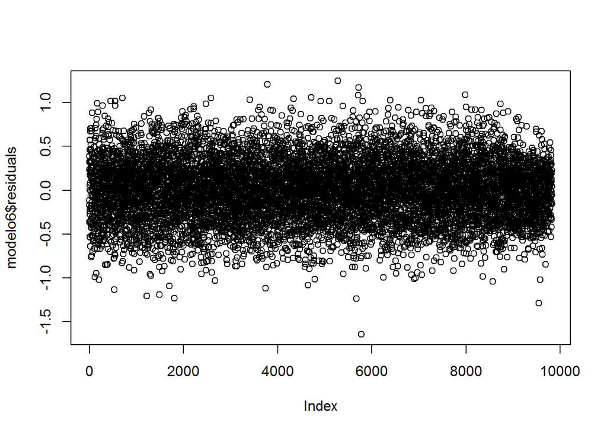

```r
plot(modelo6$residuals)
```

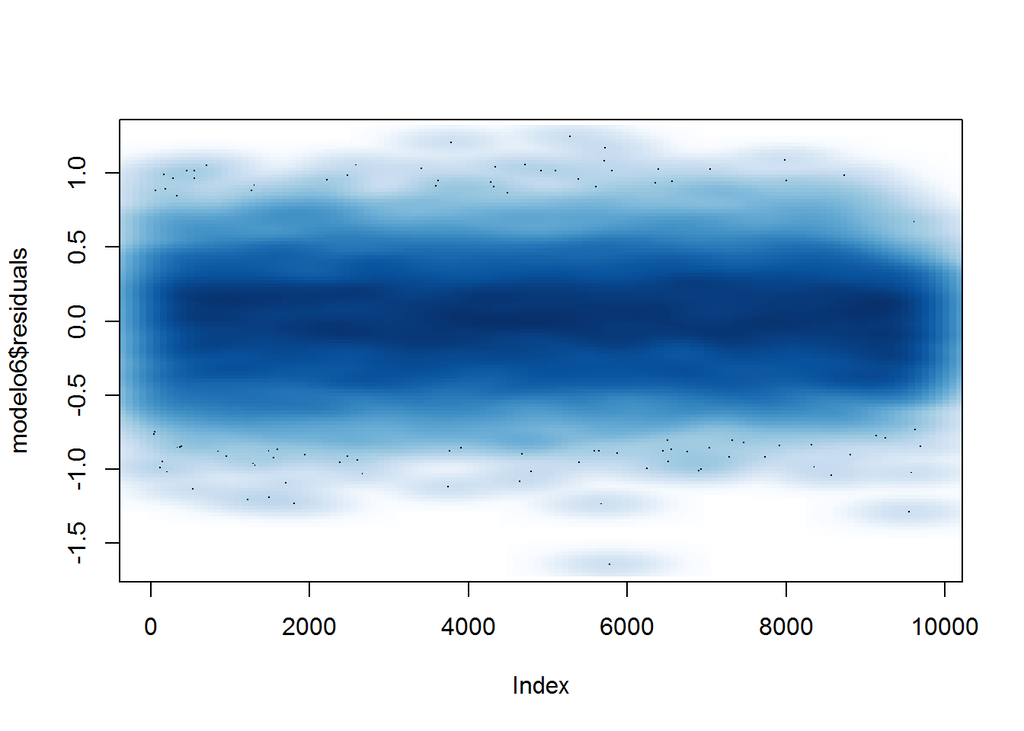

```r
smoothScatter(modelo6$residuals)
```

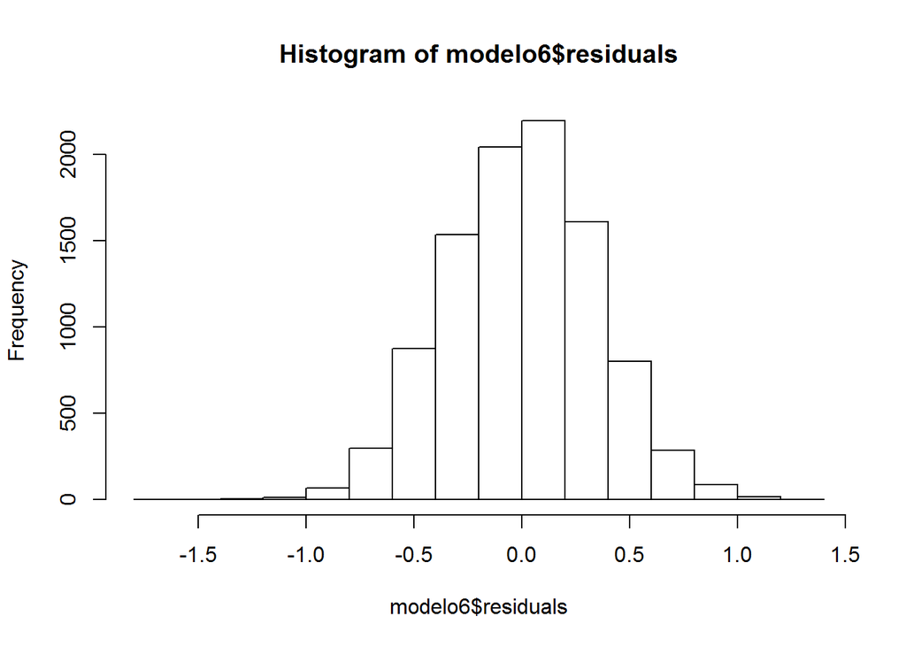

```r
hist(modelo6$residuals)
```

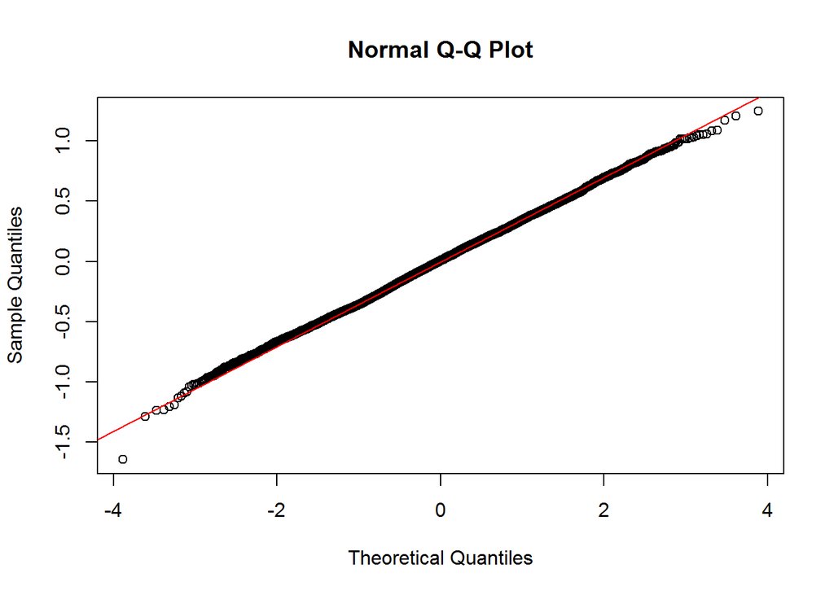

```r
qqnorm(modelo6$residuals); qqline(modelo6$residuals,col=2)
```

```r
confint(modelo6,level=0.95)
```

```
##               2.5 % 97.5 %
## (Intercept)      NA     NA
## sqft_living      NA     NA
## grade3           NA     NA
## grade4           NA     NA
## grade5           NA     NA
## grade6           NA     NA
## grade7           NA     NA
## grade8           NA     NA
## grade9           NA     NA
## grade10          NA     NA
## grade11          NA     NA
## grade12          NA     NA
## grade13          NA     NA
## sqft_above       NA     NA
## sqft_living15    NA     NA
## view1            NA     NA
## view2            NA     NA
## view3            NA     NA
## view4            NA     NA
## waterfront1      NA     NA
```

## Evaluacion del modelo

```r
house_train$prediccionLM=predict(modelo5,type="response")
R2_Train_LM=1-sum((house_train$price-house_train$prediccionLM)^2)/sum((house_train$price-mean(house_train$price))^2)

house_test$prediccionLM=predict(modelo5,newdata=house_test,type="response")
R2_Test_LM=1-sum((house_test$price-house_test$prediccionLM)^2)/sum((house_test$price-mean(house_test$price))^2)

R2_Train_LM
```

```
## [1] -1.838096
```

```r
R2_Test_LM
```

```
## [1] -2.855937
```

Lo comparamos ahora con los resultados del modelo robusto

```r
house_train$prediccionRLM=predict(modelo6,type="response")
R2_Train_RLM=1-sum((house_train$price-house_train$prediccionRLM)^2)/sum((house_train$price-mean(house_train$price))^2)

house_test$prediccionRLM=predict(modelo6,newdata=house_test,type="response")
R2_Test_RLM=1-sum((house_test$price-house_test$prediccionRLM)^2)/sum((house_test$price-mean(house_test$price))^2)

R2_Train_RLM
```

```
## [1] -1.838096
```

```r
R2_Test_RLM
```

```
## [1] -2.855937
```

```r
SCE_LM=sum((house_test$price-house_test$prediccionLM)^2) #MSE
SCE_RLM=sum((house_test$price-house_test$prediccionRLM)^2) #MSE

SCE_LM
```

```
## [1] 2.702975e+15
```

```r
SCE_RLM
```

```
## [1] 2.702975e+15
```

```r
MAE_LM=sum(abs(house_test$price-house_test$prediccionLM))
MAE_RLM=sum(abs(house_test$price-house_test$prediccionRLM))

MAE_LM
```

```
## [1] 3890632029
```

```r
MAE_RLM
```

```
## [1] 3890632031
```

## CONCLUSIONES A LOS REQUISITOS 1 y 2

- La relacion entre las variables puede decirse lineal, y representada como una ecuacion lineal (explicado anteriormente)
- Puesto que el precio no sigue una distribucion normal, lo mejor es transformarlo, por lo que la mejor relacion entre los factores que explican el precio, viene dada por la formula lineal con los factores del modleo4, que explican un 88% de la variabilidad. La interpretacion de aqui,puesto que se transforma el precio, es que el aumento de 1 unidad en cada variable afecta un % al precio